# Data 605 Homework 13

Jean Jimenez

2023-11-21

# #1

## Question

Use integration by substitution to solve the integral below

$\int 4e^{-7x} \, dx$

## Work

Let $u = -7x$

$du= -7 dx$

$dx=- \frac{1}{7} du$

That will make the integral

$\int 4e^{u} \left(-\frac{1}{7}\right) \, du$

$-\frac{4}{7} \int e^{u} du$

Which is:

$-\frac{4}{7} e^{u} + C$

$-\frac{4}{7} e^{-7x} + C$

## Answer

$\int 4e^{-7x} \, dx= -\frac{4}{7} e^{-7x} + C$

# #2

## Question

Biologists are treating a pond contaminated with bacteria. The level of contamination is changing at a rate of $\frac{dN}{dt}=-\frac{3150}{t^4}-220$ bacteria per cubic centimeter per day, where t is the number of days since treatment began.

Find a function N( t ) to estimate the level of contamination if the level after 1 day was 6530 bacteria per cubic centimeter.

## Work and Answer

```r
library(pracma)
dN_dt = function(t) {
    -3150 / t^4 - 220
}

n_t = function(t) {
    int = integral(dN_dt, 1, t)
    n_1 = 6530
    n_t = int + n_1
    return(n_t)
}

n_t(8)
```

```
## [1] 3942.051
```

The function n_t represents the answer N(t). For example; after 8 days, the level of contamination is estimated to be 3942.051.

# #3

## Question

Find the total area of the red rectangles in the figure below, where the equation of the line is $f(x)=2x-9$

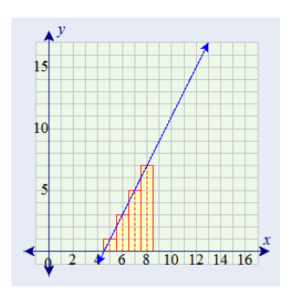

## Work and Answer

I will estimate the area under the line using reimann sum.

```r
f = function(x) {
  2 * x - 9
}

total_area = 0

for (x in seq(4.5, 7.5, by = 1)) {
  height = f(x)
  width = 1
  total_area = total_area + height * width
}

cat("The total area of the red rectanges is", total_area, "units cubed \n")
```

[output not shown]

# #4

## Question

Find the area of the region bounded by the graphs of the given equations:

$y=x^2-2x-2 , y=x+2$

## Work and Answer

```r
y1 = function(x) { x^2 - 2*x - 2 }
y2 = function(x) { x + 2 }

#points of intersection

points_of_intersection = function() {
#quadratic form
  solutions = polyroot(c(-4, -3, 1))
  #only real no imaginary
  real_solutions = Re(solutions)
  return(real_solutions)
}

# area btween functions
find_area = function(intersections) {
  area = integrate(function(x) { y2(x) - y1(x) }, min(intersections), max(intersections))$value
  #abs bc area is positive
  return(abs(area))
}

#points of intersections and bounds
intersections = points_of_intersection()
area4 = find_area(intersections)


cat("The area between the two functions is", area4, "units squared. \n")
```

```
## The area between the two functions is 20.83333 units squared.
```

# #5

## Question

A beauty supply store expects to sell 110 flat irons during the next year. It costs $3.75 to store one flat iron for one year.

There is a fixed cost of $8.25 for each order. Find the lot size and the number of orders per year that will minimize inventory costs.

## Work and Answer

```r
demand= 110
fixed_cost=8.25
hold_cost=3.75


#EOQ forumla

quant=sqrt((2*demand*fixed_cost)/hold_cost)
order_n=demand/quant

cat("The order quantity that minimizes inventory costs is", quant, "flat irons \n")
```

```
## The order quantity that minimizes inventory costs is 22 flat irons
```

```r
cat("The number of orders per year that minimizes inventory costs is", order_n, "orders \n")
```

```
## The number of orders per year that minimizes inventory costs is 5 orders
```